# Exercise 2

## Time Series Analysis & Recurrent Neural Networks, SoSe 2021

### Author: Elias Olofsson

```
Version information:
    2021-05-05: v.1.0. First public release.
```

```python
import numpy as np
import pandas as pd
import matplotlib.pyplot as plt
plt.rc('image', cmap='gray')

from sklearn.linear_model import LinearRegression

# Notebook graphics settings
#%config InlineBackend.figure_format = 'svg'    # inline vector graphics
#%config InlineBackend.figure_format = 'retina' # medium resolution png:s
plt.rcParams['figure.dpi'] = 120                # custom dpi setting png
```

## Task 1: AR(p) models

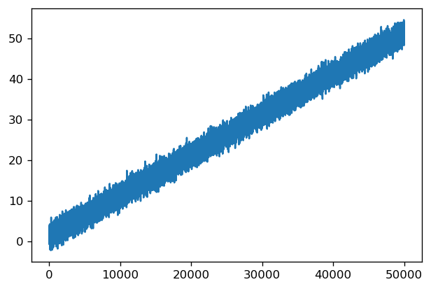

```python
# Loading the time series.
data1 = np.loadtxt('Tut2_file1.txt')

# Plotting the raw data
plt.plot(data1)
plt.show()
```

```python
def AR_fit(x, p):
    """
    Estimate the parameters of an Auto-regressive (AR) model
    of order p on a scalar time series x.

    Parameters:
    -----------
    x: np.array shape=(T,)
        Scalar valued time series.
    p: int
        Order of the AR process.

    Returns:
    --------
    coef: np.array shape=(p,)
        Coefficient estimates of the AR(p) model.
    """
    T = len(x)
    y = x[p:] # target vector

    # Regressor matrix
    X = np.zeros((T-p, p+1))    # pre-allocation
    X[:,0] = 1                  # absorbing intercept by a column of ones.
    for i in range(1, p+1):
        X[:,i] = x[p-i:T-i]     # building the regressor matrix

    # Linear regression.
    reg = LinearRegression().fit(X, y)
    return reg.coef_
```

```python
# Coefficient estimation of AR(1) model on raw data.
print(AR_fit(data1, 1))
```

```
[0.         0.99702754]
```

We obtain a coefficient estimate $a_1 \sim 1$, which is very close to the threshold for divergence (sufficient condition $|a_1|>1$ for divergence of an AR process). When $a_1 = 1$ the process is a random walk, which is what we can visually see in our time series. I was however expecting that we would have $a_0 \neq 0$ since we have a steady increasing trend in our TS. Not sure if this is due to an incorrect implementation by me, or if I haven't fully understood the thoery.

```python
# Fitting linear model to TS.
X = np.vstack((np.ones(len(data1)), np.arange(len(data1)))).T
reg = LinearRegression().fit(X, data1)
print(reg.coef_)
```

```
[0.         0.00100007]
```

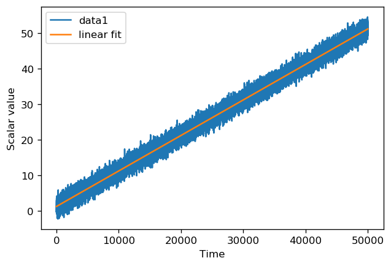

```python
# Visualizing the linear fit.
plt.plot(data1, label='data1')
plt.plot(X[:,1], reg.predict(X), label='linear fit')
plt.xlabel('Time')
plt.ylabel('Scalar value')
plt.legend()
plt.show()
```

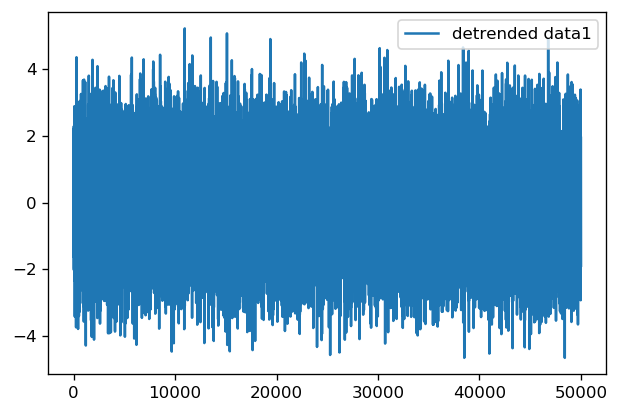

```python
# Detrending the TS
data1_detrend = data1 - reg.predict(X)
plt.plot(data1_detrend, label='detrended data1')
plt.legend()
plt.show()
```

```python
# Coefficient estimation of AR(1) model on detrended data.
print(AR_fit(data1_detrend, 1))
```

```
[0.         0.60289581]
```

We no longer have $a_1 \sim 1$, and as such there is no longer any random walk present. Instead, the TS is stable and irregularly oscillates around 0.

```python
def AR1_step(x0, coef):
    """
    Take a single AR(1) step.
    """
    return coef.dot(np.array([1, x0])) + np.random.normal()

def stepping(n_steps, method, x0, coef):
    """
    Step n_steps into the future following the select method.
    """
    x = x0
    for i in range(n_steps):
        x = method(x0, coef)
    return x
```

```python
def future_stepping(x, n_steps, method, coef):
    """
    Estimating n_steps future steps following an AR(p) model, starting at each timestep
    from true inital data. Calculates and returns the total squared residual average.
    """
    # Organisation and pre-allocation.
    x_init    = x[:-n_steps]
    x_truth   = x[n_steps:]
    x_predict = np.zeros_like(x_init)

    # For each timestep, estimate n_steps into the future.
    for i in range(len(x_init)):
        x_predict[i] = stepping(n_steps, method, x_init[i], coef)

    # Calculate squared residual average.
    residual = np.mean((x_predict - x_truth)**2)
    return residual, x_truth, x_predict
```

```
Average squared residual = 3.909929885830531
```

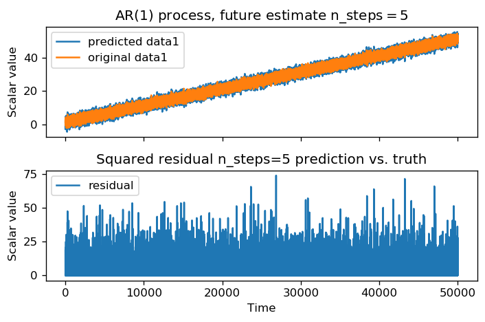

```python
p = 1
coef_data1 = AR_fit(data1, p) # Get AR(p) coefficients on original data.

n_steps = 5
residual, x_truth, x_predict = future_stepping(data1, n_steps, AR1_step, coef_data1)
print(f"Average squared residual = {residual}")

# Plotting.
fig, ax = plt.subplots(2, 1, sharex=True)

ax[0].plot(x_predict, label='predicted data1')
ax[0].plot(x_truth, label='original data1')
ax[0].set_ylabel('Scalar value')
ax[0].set_title(f'AR({p}) process, future estimate n_steps$={n_steps}$')
ax[0].legend()

ax[1].plot((x_predict-x_truth)**2, label='residual')
ax[1].set_title(f'Squared residual n_steps={n_steps} prediction vs. truth')
ax[1].set_xlabel('Time')
ax[1].set_ylabel('Scalar value')
ax[1].legend()
fig.tight_layout()
plt.show()
```

```
Average squared residual = 2.2623297963988596
```

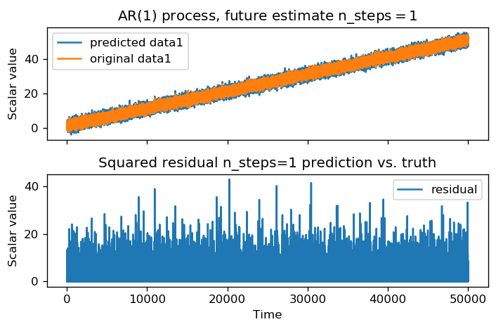

```python
n_steps = 1
residual, x_truth, x_predict = future_stepping(data1, n_steps, AR1_step, coef_data1)
print(f"Average squared residual = {residual}")

# Plotting.
fig, ax = plt.subplots(2, 1, sharex=True)

ax[0].plot(x_predict, label='predicted data1')
ax[0].plot(x_truth, label='original data1')
ax[0].set_ylabel('Scalar value')
ax[0].set_title(f'AR({p}) process, future estimate n_steps$={n_steps}$')
ax[0].legend()

ax[1].plot((x_predict-x_truth)**2, label='residual')
ax[1].set_title(f'Squared residual n_steps={n_steps} prediction vs. truth')
ax[1].set_xlabel('Time')
ax[1].set_ylabel('Scalar value')
ax[1].legend()
fig.tight_layout()
plt.show()
```

## Task 2: Estimating an AR(1) model

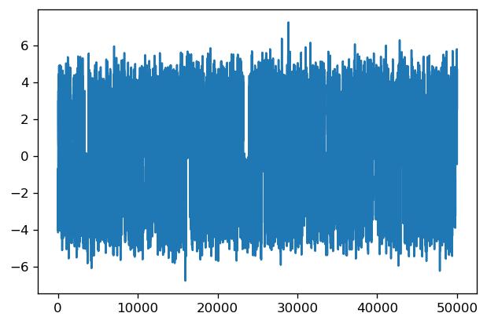

```python
# Loading the time series.
data2 = np.loadtxt('Tut2_file2.txt')

# Plotting the raw data
plt.plot(data2)
plt.show()
```

```python
# Coefficient estimation of AR(1) model on raw data.
print(AR_fit(data2, 1))
```

```
[0.         0.87313166]
```

```python
def return_plot_data(x, order):
    """
    Generate x and y data for an n:th order return plot.
    """
    x_out = x[:-order]
    y_out = x[order:]

    plt.scatter(x_out, y_out, s=10, alpha=0.25)
    plt.xlabel(f'$x_{{t-{order}}}$')
    plt.ylabel('$x_{t}$')
    if order%10 == 1:
        plt.title(f'{order}st order return')
    elif order%10 == 2:
        plt.title(f'{order}nd order return')
    elif order%10 == 3:
        plt.title(f'{order}rd order return')
    else:
        plt.title(f'{order}th order return')
    plt.show()
```

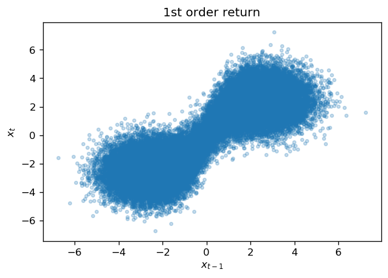

```python
return_plot_data(data2, 1)
```

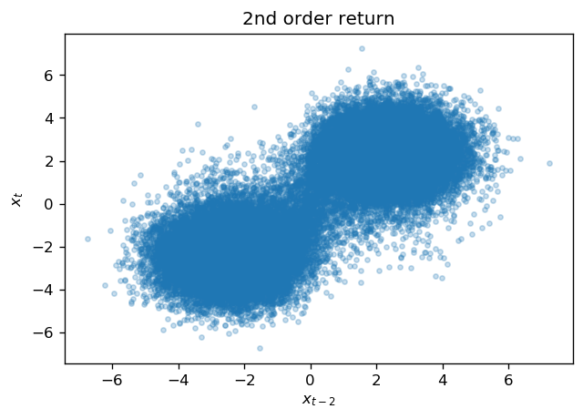

```python
return_plot_data(data2, 2)
```

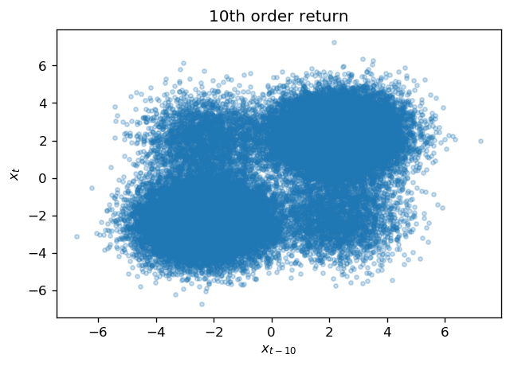

```python
return_plot_data(data2, 10)
```

As seen in the return plots above, we can most likely not fit a linear model to a signal of this type, due to the very apparent non-linearity present in the TS.

I did not understand fully what 'examine the autocorrelations in the residuals' mean, but below I have plotted the autocorrelations of the time series, and similarly to task 1, predicted data 5 timesteps into the future from a fitted AR(1) model, and plotted the autocorrelation of these residuals.

Not sure if this was what the instructions meant, and I have no idea on how to interpret the 'autocorrelation on the residuals'.

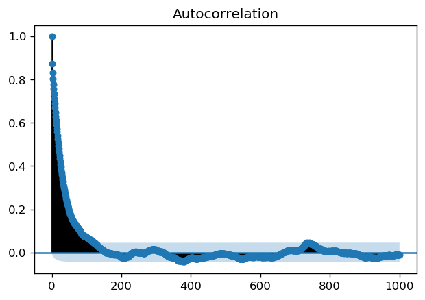

```python
from statsmodels.graphics.tsaplots import plot_acf

plot_acf(data2, lags=1000)
plt.show()
```

Doesn't seems to be any clear repeating cycles in the raw time series data.

```
Average squared residual = 3.8236125704969033
```

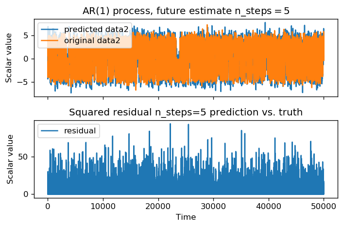

```python
p = 1
coef_data2 = AR_fit(data2, p) # Get AR(p) coefficients on original data.

n_steps = 5
residual, x_truth, x_predict = future_stepping(data2, n_steps, AR1_step, coef_data2)
print(f"Average squared residual = {residual}")

# Plotting.
fig, ax = plt.subplots(2, 1, sharex=True)

ax[0].plot(x_predict, label='predicted data2')
ax[0].plot(x_truth, label='original data2')
ax[0].set_ylabel('Scalar value')
ax[0].set_title(f'AR({p}) process, future estimate n_steps$={n_steps}$')
ax[0].legend()

ax[1].plot((x_predict-x_truth)**2, label='residual')
ax[1].set_title(f'Squared residual n_steps={n_steps} prediction vs. truth')
ax[1].set_xlabel('Time')
ax[1].set_ylabel('Scalar value')
ax[1].legend()
fig.tight_layout()
plt.show()
```

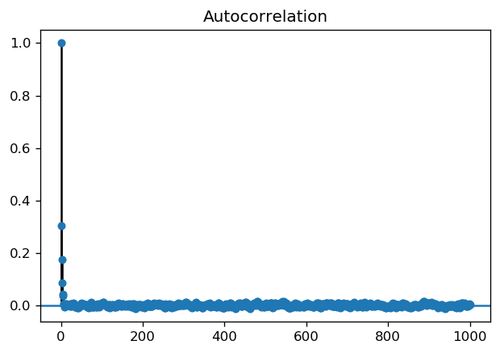

```python
# Auto-correlations in the residuals (?)
plot_acf((x_predict-x_truth)**2, lags=1000)
plt.show()
```

Not sure on how to interpret this more than that there is no repeating cycles (only noise) in the 'autocorrelations in the residuals'.

## Task 3: Autocorrelation and partial autocorrelation.

```
(10000, 2)
```

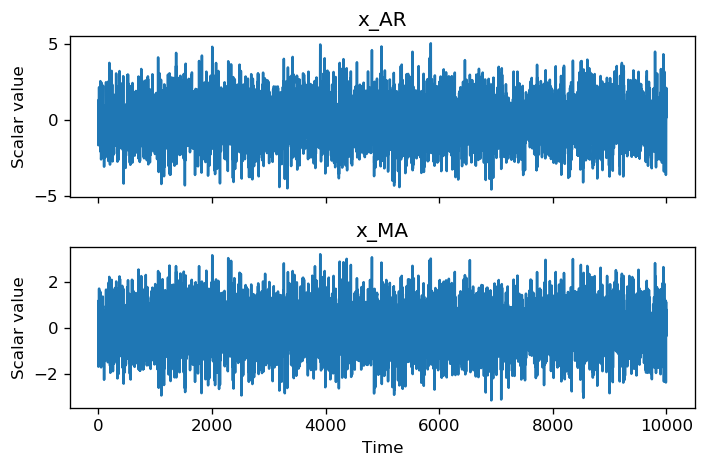

```python
# Loading the time series.
data3 = np.loadtxt('Tut2_file3.txt', skiprows=1)
print(data3.shape)

x_AR = data3[:, 0]
x_MA = data3[:, 1]

# Plotting the raw data.
fig, ax = plt.subplots(2, 1, sharex=True)

ax[0].plot(x_AR, label='x_AR')
ax[0].set_title('x_AR')
ax[0].set_ylabel('Scalar value')

ax[1].plot(x_MA, label='x_MA')
ax[1].set_title('x_MA')
ax[1].set_xlabel('Time')
ax[1].set_ylabel('Scalar value')

fig.tight_layout()
plt.show()
```

```python
def acorr(x, lags):
    """
    Determines auto-correlation for a time series x over sweep
    of time-lags in interval [0, lags).
    """
    acorr_arr = np.zeros(lags)
    for i in range(lags):
        # Relative time shift
        if i > 0:
            x1 = x[:-i]
            x2 = x[i:]
        else:
            x1 = x
            x2 = x
        gamma_x1_x2  = ((x1-x1.mean())*(x2-x2.mean())).mean() # xcov(x1, x2)
        std_x1       = np.sqrt(((x1-x1.mean())**2).mean())    # std(x1)
        std_x2       = np.sqrt(((x2-x2.mean())**2).mean())    # std(x2)
        acorr_arr[i] = gamma_x1_x2 / (std_x1 * std_x2)        # acorr(x) = xcorr(x1,x2)
    # Plotting.
    plt.plot(acorr_arr, '-o')
    plt.title('Autocorrelation')
    plt.xlabel('Time-lag')
    plt.show()
```

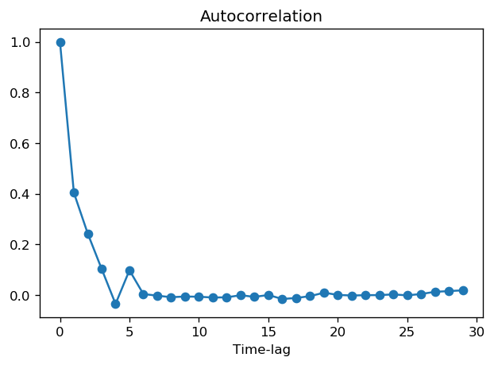

```python
acorr(x_MA, 30) # Moving average process.
```

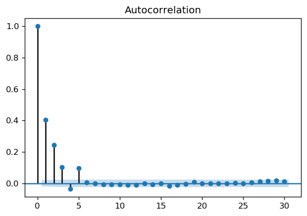

```python
# Using statsmodels package for verification
plot_acf(x_MA, lags=30)
plt.show()
```

Studying the autocorrelation diagram for the moving average process, we can determine the order q of the MA(q) process to q=5.

```python
def pacorr(x, lags):
    """
    Determines partial auto-correlation for a time series x over sweep
    of time-lags in interval [0, lags).
    """
    pacorr_arr = np.zeros(lags)
    for i in range(lags):
        # Relative time shift.
        if i > 0:
            x1 = x[:-i].copy()
            x2 = x[i:].copy()
        else:
            x1 = x.copy()
            x2 = x.copy()

        if i > 1:
            # We have intermediate lags between x1 and x2. Find their linear dependence on x1 and x2.
            # Form a matrix X with concatenations of the intermediate lags for the TS.
            X = np.zeros((len(x1), i-1))
            for idx, j in enumerate(range(1, i)):
                X[:, idx] = x[j:-i+j]
            reg1 = LinearRegression().fit(X, x1) # Linear fit of intermediate lags to x1.
            reg2 = LinearRegression().fit(X, x2) # Linear fit of intermediate lags to x2.
            x1 -= reg1.predict(X) # Remove linear dependence on the intermediate lags.
            x2 -= reg2.predict(X)

        # Calculate the autocorrelation.
        gamma_x1_x2  = ((x1-x1.mean())*(x2-x2.mean())).mean() # xcov(x1, x2)
        std_x1       = np.sqrt(((x1-x1.mean())**2).mean())    # std(x1)
        std_x2       = np.sqrt(((x2-x2.mean())**2).mean())    # std(x2)
        pacorr_arr[i] = gamma_x1_x2 / (std_x1 * std_x2)        # acorr(x) = xcorr(x1,x2)

    # Plotting.
    plt.plot(pacorr_arr, '-o')
    plt.title('Partial auto-correlation')
    plt.xlabel('Time-lag')
    plt.show()
```

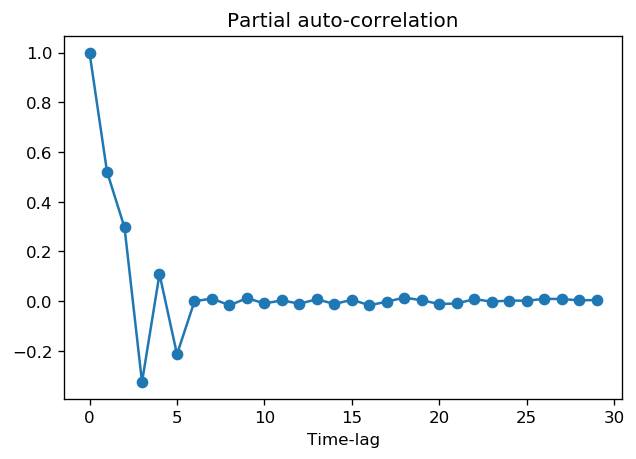

```python
pacorr(x_AR, 30) # Auto-regressive process.
```

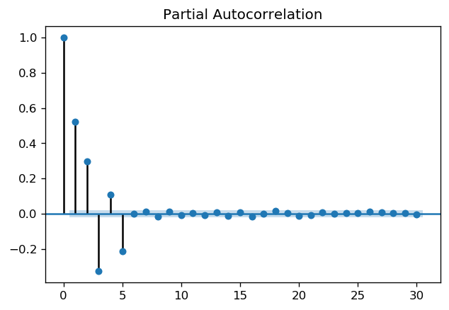

```python
# Using statsmodels package for verification
from statsmodels.graphics.tsaplots import plot_pacf
plot_pacf(x_AR, lags=30)
plt.show()
```

Studying where the partial autocorrelation function decays to zero, we can determine the AR process to be of order p=5.